# Participation in the Crowdsourced Reform of Finland’s Condominium-Law

Jorge Saldivar

4 Feb 2015

Study on the dynamics of participation detected in the Finland idea crowdsourcing condominium law-reform process conducted in the idea management system [IdeaScale](http://www.ideascale.com). During the process, ideas were collected under three meta-topics or campaigns: governance, communication and conflicts in the homeowners’ association.

### Data Snippet

| id | ideas | votes | comments |
| --- | --- | --- | --- |
| 2612408 | 0 | 6 | 0 |
| 2612409 | 0 | 11 | 0 |
| 2612410 | 3 | 103 | 5 |
| 2612411 | 0 | 0 | 0 |
| 2612412 | 0 | 5 | 1 |
| 2612413 | 2 | 26 | 12 |

### Participation

From the **362** users registered as participants, **155 (42.8%)** have actually contributed to at least one of the campaigns in some way, i.e., submitting ideas, placing comments and/or voting, while **207 (57.2%)** only observed the activity.

Most of the content was generated by **56** participants **(15.5% of the 362)**, who have actively taken part in the process by posting ideas, and placing comments and voting, i.e., generated the three type of content. The remaining **99 (27.3%)** participants contributed with some additional ideas, comments, and votes.

Out of the **155** contributors, **56 (36.1%)** have generated the three type of content (ideas, votes, and comments), **20 (12.9%)** have submitted ideas and posted votes but not comments, and **79 (51%)** have contributed by only commenting on the existing ideas.

### Distribution of Idea Production

How the production of ideas was distributed throughout participants.

*Obs. Users that didn’t produce any idea as well as those outliers were removed before plotting.*

#### In Total

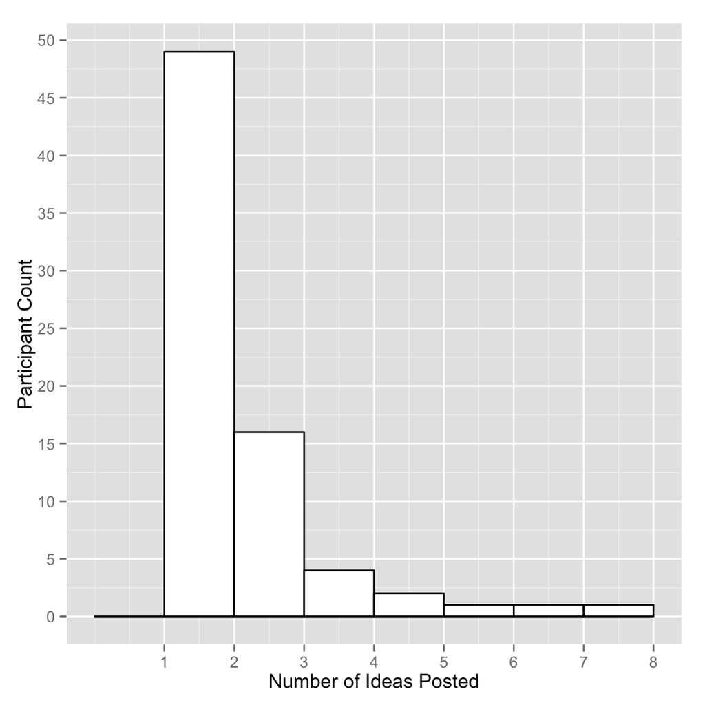

#### Per Campaign

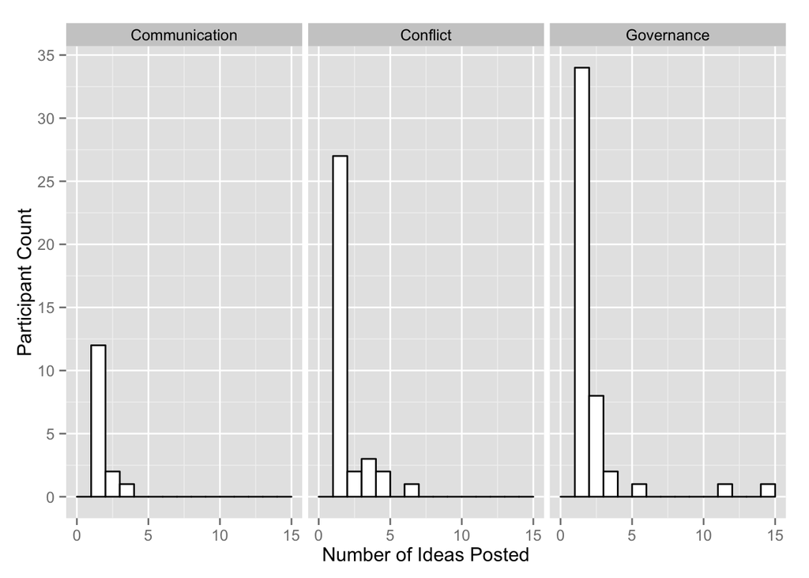

#### General Statistics

```
## Total Ideas:  159
## Total Ideators:  76  ( 20.99%  of the participants )
```

*Five-number summary*

```
##    Min. 1st Qu.  Median    Mean 3rd Qu.    Max.
##   0.000   0.000   0.000   1.026   1.000  22.000
```

### Distribution of Comment Production

How the production of comments was distributed throughout participants.

*Obs. Users that didn’t post any comment as well as those outliers were removed before plotting.*

#### In General

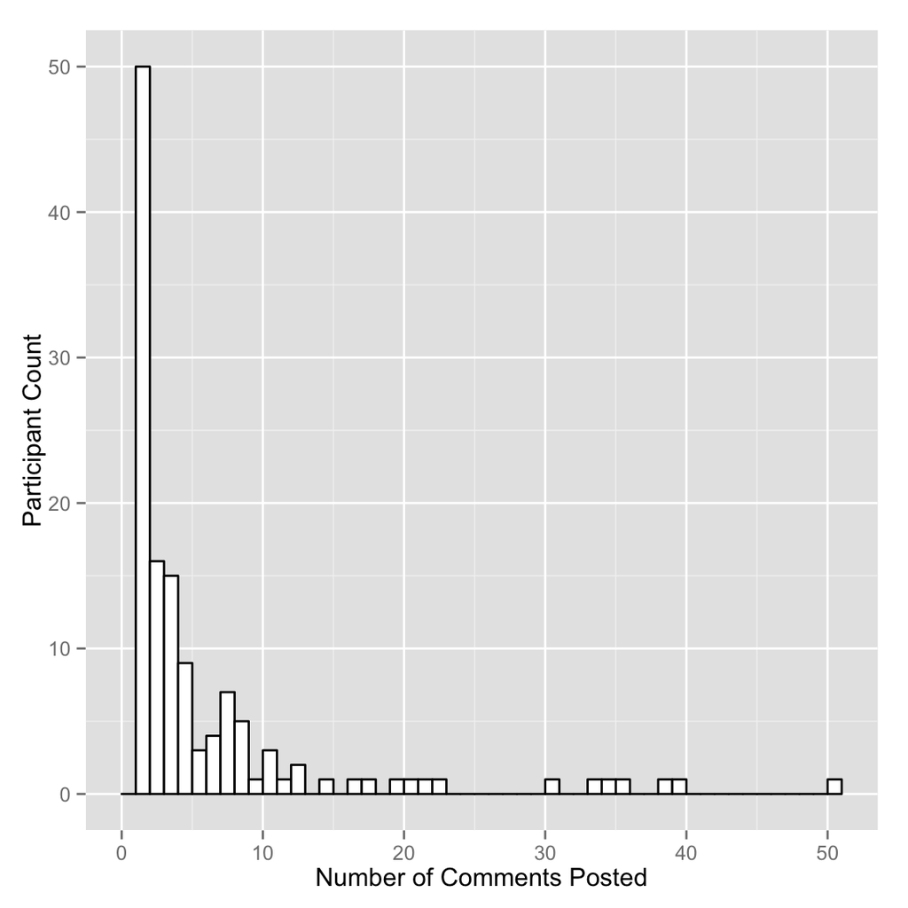

#### Per Campaign

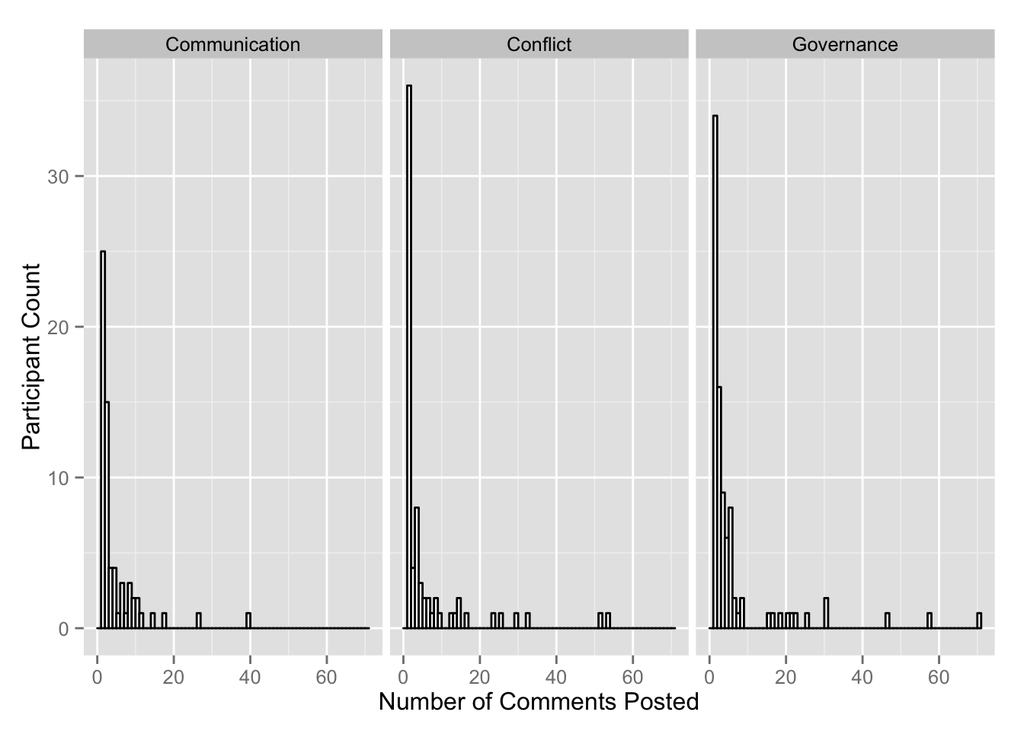

#### General Statistics

```
## Total Comments:  1260
## Total Commenters:  135  ( 37.29%  of the participants )
```

*Five-number summary*

```
##    Min. 1st Qu.  Median    Mean 3rd Qu.    Max.
##   0.000   1.000   2.000   8.129   6.000 160.000
```

### Distribution of Votes

How the generation of votes was distributed throughout participants.

*Obs. Users that didn’t vote as well as those outliers were removed before plotting.*

#### In General

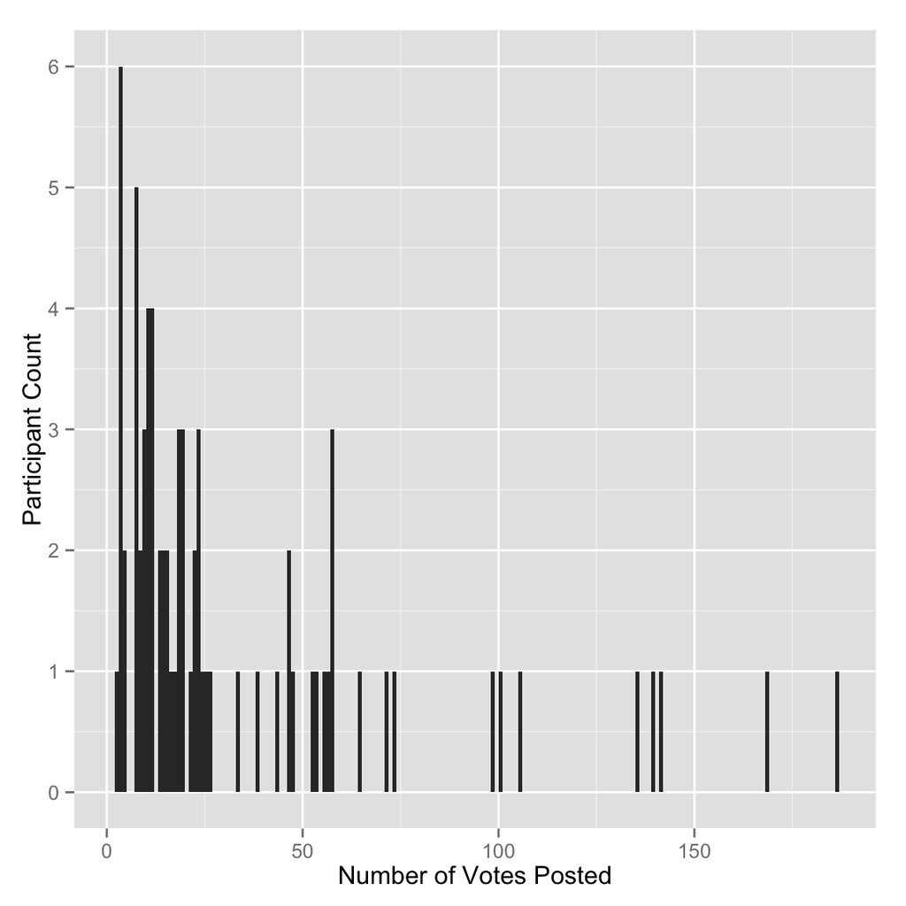

#### Per Campaign

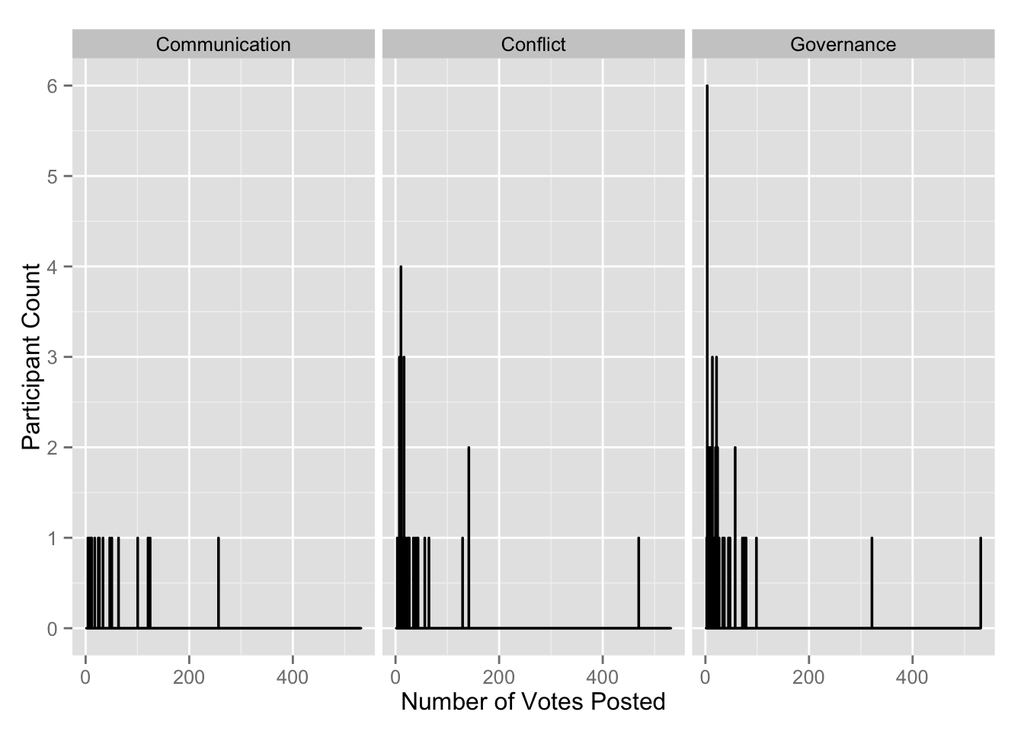

#### General Statistics

```
## Total Votes:  4315
## Total Voters:  76  ( 20.99%  of the participants )
```

*Five-number summary*

```
##    Min. 1st Qu.  Median    Mean 3rd Qu.    Max.
##    0.00    0.00    0.00   27.84   18.00 1256.00
```

#### Statistics per Campaign

| campaign | participants | ideas | comments | votes |
| --- | --- | --- | --- | --- |
| Communication | 69 | 19 | 282 | 891 |
| Governance | 103 | 86 | 562 | 1948 |
| Conflict | 82 | 54 | 416 | 1476 |

#### Productivity per Campaign

| campaign | ideas_per_participants | comments_per_participants | votes_per_participants |
| --- | --- | --- | --- |
| Communication | 0.30 | 4.10 | 12.90 |
| Governance | 0.80 | 5.50 | 18.90 |
| Conflict | 0.70 | 5.10 | 18.00 |